# Which London Boroughs Have More Crime, and What Best Explains the Difference?

London’s crime map is not evenly spread out. Some boroughs sit persistently far above the rest, while others remain much lower. Using a borough-level panel dataset from 2019 to 2024, this project compares claimant rate, deprivation, and population density to identify which factor is most strongly associated with crime per 1,000 residents. The clearest result is that population density stands out as the strongest factor in the final comparison, however, this blog will show you why.

```python
from pathlib import Path
from IPython.display import Image, display
import pandas as pd

ROOT = Path(".")
SEARCH_DIRS = [
    ROOT,
    ROOT / "output" / "exploration" / "figures",
    ROOT / "output" / "analysis" / "figures",
]

def show_fig(*candidates, width=950):
    for candidate in candidates:
        p = Path(candidate)
        if p.exists():
            display(Image(filename=str(p), width=width))
            return
        for base in SEARCH_DIRS:
            q = base / candidate
            if q.exists():
                display(Image(filename=str(q), width=width))
                return
    print("Missing file. Tried:")
    for candidate in candidates:
        print("-", candidate)

pd.set_option("display.max_colwidth", None)
```

London is often discussed as if “crime in the city” is one single problem, however, this hides major differences between boroughs. Westminster does not look like Harrow. Camden does not look like Bromley. Once crime is adjusted for population size, the gap between boroughs is still very large, which suggests that local borough conditions matter, not just city-wide trends.

This project asks a focused question. Which borough-level factors are most strongly associated with crime per 1,000 population across London boroughs from 2019 to 2024? To help answer this question, we compare three candidates: claimant rate, deprivation, and population density. The way it is done is by using a cleaned borough-month panel, descriptive analysis, simple correlations, and a standardised regression-style comparison. Across all of those steps, the same variable keeps rising to the top: population density.

## The data behind the story

The final merged dataset contains 2,304 observations covering 32 London boroughs, observed monthly from 2019 to 2024. It was built by combining crime, population, density, labour-market claimant, and deprivation data into one borough-month panel. The final file has 11 columns, no missing values, and no duplicate rows, which makes it a solid base for comparison.

The cleaning and merging stage matters because fair comparison depends on it. Borough names had to be standardised across files, and the labour dataset originally contained duplicate borough-year-month rows, which were fixed before the final merge. The final panel keeps only the 32 boroughs common to all required sources.

Just as importantly, the analysis uses crime per 1,000 population rather than raw crime totals. This avoids treating larger boroughs as automatically more crime-heavy simply because they have more residents. Across the whole panel, the mean crime rate is 8.21 per 1,000, with observed values ranging from 3.56 to 45.13, so there is substantial variation to explain.

## Crime over time: London does not stay still

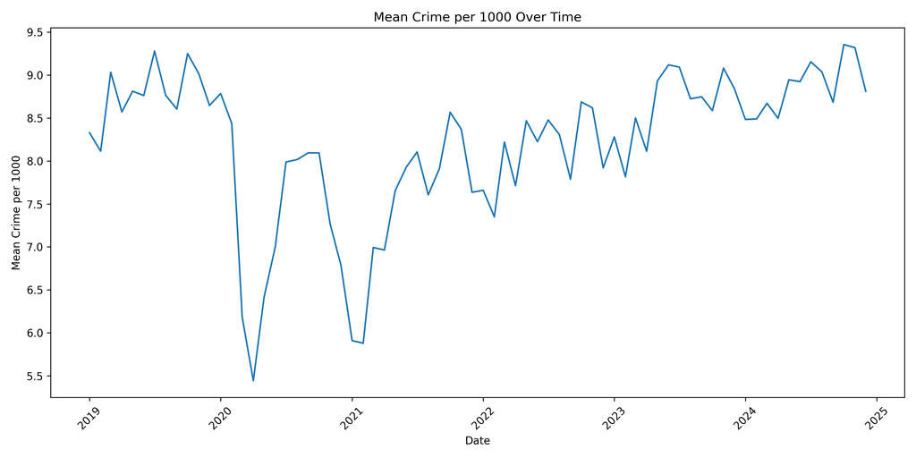

```python
show_fig("mean_crime_per_1000_over_time.png")
```

The first thing to establish is that the overall level of crime changed over time. The lowest yearly mean crime rate in the dataset occurs in 2020, at 7.38 per 1,000, while the highest occurs in 2024, at 8.86 per 1,000. The broader pattern is a fall in the earlier part of the period followed by a rise again by 2023–2024. An explanation for the dip in 2020, could be because of Covid-19, as people had to stay at home. Suggetsing less, street and house theft.

## Borough differences are large, and hard to ignore

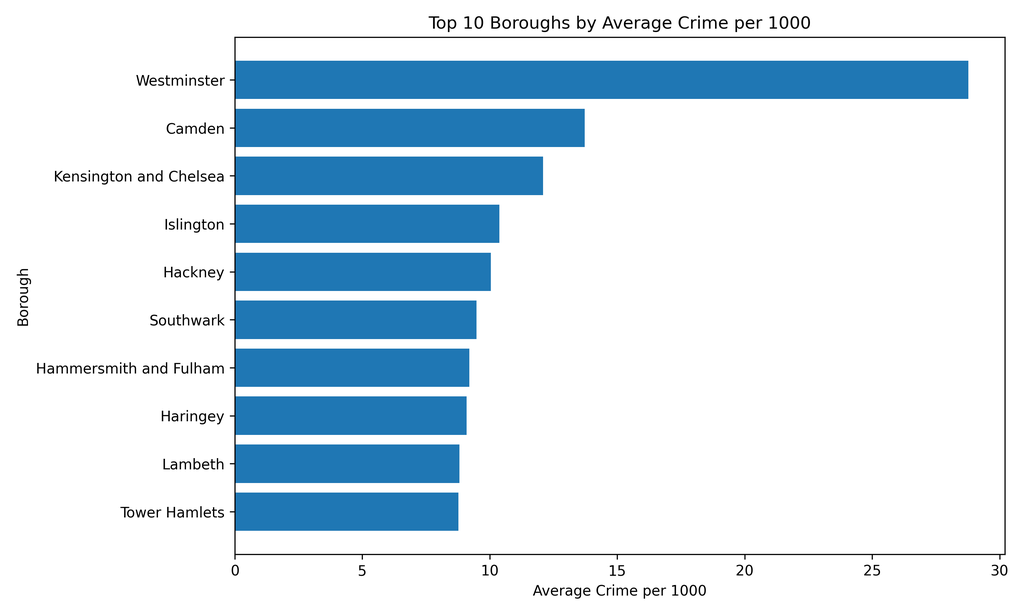

```python
show_fig("top10_boroughs_crime_per_1000.png")
```

Even after adjusting for population, crime rates vary sharply across boroughs. The highest average borough in the dataset is Westminster, with 28.77 crimes per 1,000 population, while the lowest is Harrow, with 4.93. That is a gap of 23.83 crimes per 1,000, which is too large to dismiss as noise.

Behind Westminster come Camden (13.72) and Kensington and Chelsea (12.09), followed by Islington (10.38) and Hackney (10.05). At the lower end sit boroughs such as Richmond upon Thames (5.05), Sutton (5.21), Merton (5.28) and Harrow (4.93). As we can see from this data, the top 3 places with crime are all in high networth areas. Which makes sense as there are high rewards to steal here.

## Table 1. The key results in one place

```python
key_results = pd.DataFrame({
    "Measure": [
        "Highest average crime per 1,000",
        "Lowest average crime per 1,000",
        "Highest yearly mean crime per 1,000",
        "Lowest yearly mean crime per 1,000",
        "Strongest simple correlation",
        "Second strongest simple correlation",
        "Weakest simple correlation",
        "Strongest combined-model predictor",
        "Weakest combined-model predictor",
        "Model R-squared"
    ],
    "Result": [
        "Westminster (28.77)",
        "Harrow (4.93)",
        "2024 (8.86)",
        "2020 (7.38)",
        "population_density (0.5293)",
        "imd_value (0.2510)",
        "claimant_per_1000 (0.1963)",
        "population_density (0.5946)",
        "imd_value (0.0676)",
        "0.2937"
    ]
})

key_results
```

|  | Measure | Result |
| --- | --- | --- |
| 0 | Highest average crime per 1,000 | Westminster (28.77) |
| 1 | Lowest average crime per 1,000 | Harrow (4.93) |
| 2 | Highest yearly mean crime per 1,000 | 2024 (8.86) |
| 3 | Lowest yearly mean crime per 1,000 | 2020 (7.38) |
| 4 | Strongest simple correlation | population_density (0.5293) |
| 5 | Second strongest simple correlation | imd_value (0.2510) |
| 6 | Weakest simple correlation | claimant_per_1000 (0.1963) |
| 7 | Strongest combined-model predictor | population_density (0.5946) |
| 8 | Weakest combined-model predictor | imd_value (0.0676) |
| 9 | Model R-squared | 0.2937 |

This table gives a compact summary of the main findings before turning to each predictor separately.

## Claimant rate: intuitive, but not convincing enough

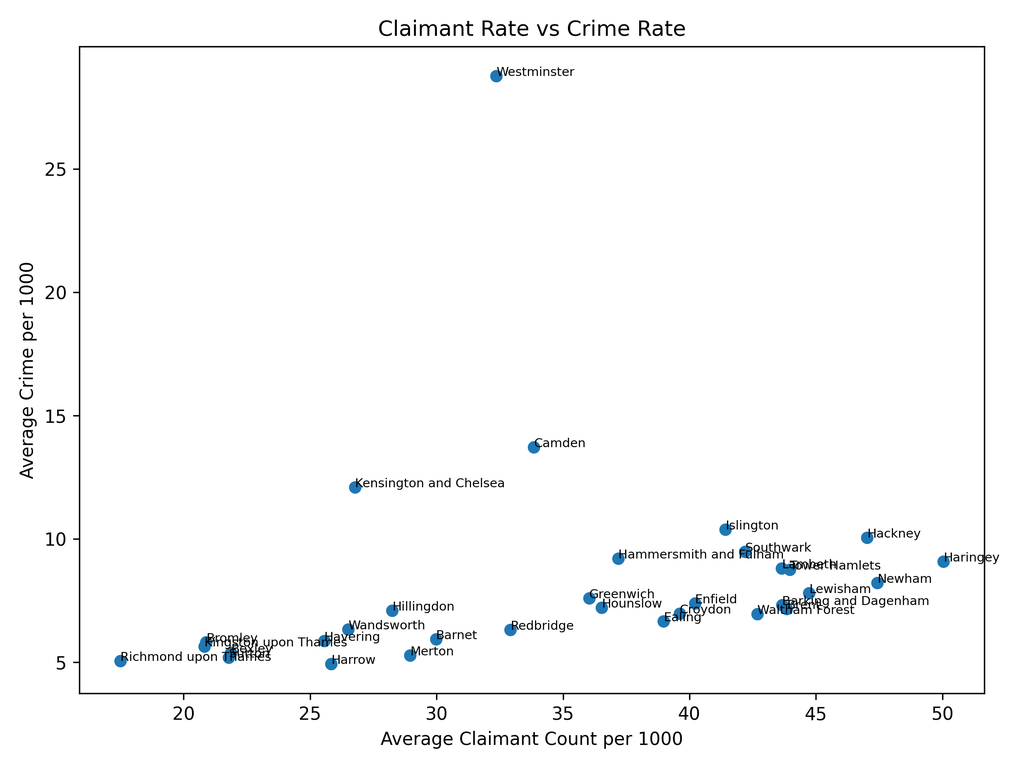

```python
show_fig("claimant_vs_crime_rate.png", "claimant_per_1000_vs_crime_per_1000.png")
```

Claimant rate is an understandable place to start. It seems plausible that boroughs with greater labour-market difficulty might also face higher crime. However, the evidence here is weaker than that story suggests. In the simple correlation comparison, claimant_per_1000 has the weakest relationship with crime per 1,000 at 0.1963.

The yearly data strengthen that point. Shown as the mean claimant rate per 1,000 rises sharply from 18.28 in 2019 to 42.59 in 2020 and 48.42 in 2021, yet those are also the years when mean crime per 1,000 is lowest or near-lowest. Therefore, the time-series evidence does not support a simple “more claimants, more crime” story.

## Deprivation: relevant, but not dominant

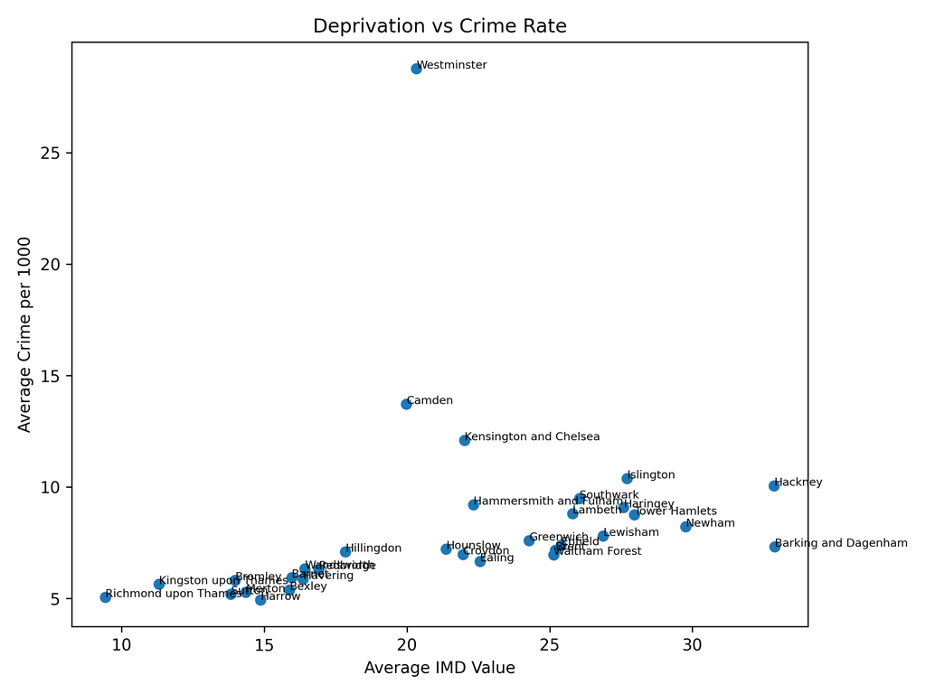

```python
show_fig("deprivation_vs_crime_rate.png", "imd_value_vs_crime_per_1000.png")
```

Deprivation performs better than claimant rate, but still not strongly enough to lead the story. In the simple correlation table, imd_value is the second strongest predictor at 0.2510. That means it does have a positive relationship with crime per 1,000, but it is still far below population density.

More importantly, deprivation weakens sharply in the combined model. Its standardised coefficient falls to just 0.0676, the smallest of the three predictors. So deprivation is part of the picture, but not enough to explain the biggest borough differences on its own.

## Population density: the clearest relationship in the data

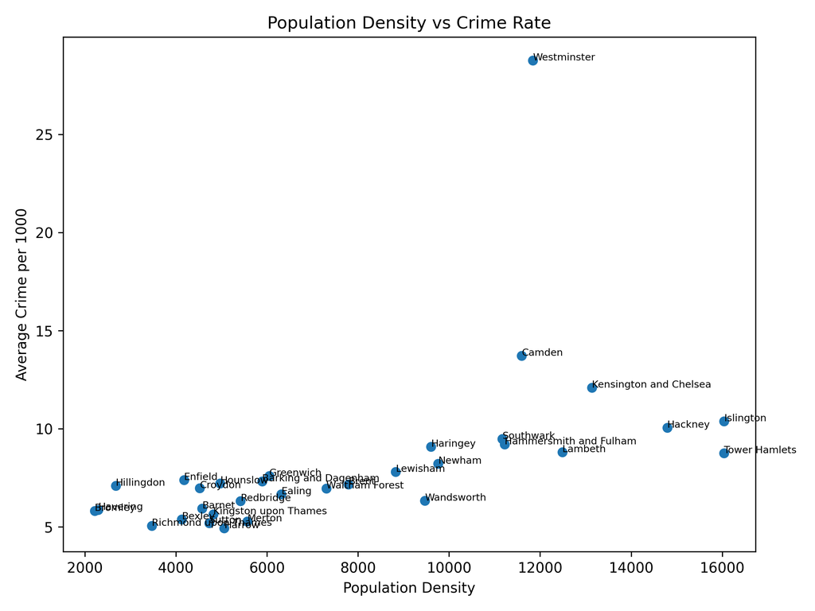

```python
show_fig("density_vs_crime_rate.png", "population_density_vs_crime_per_1000.png")
```

This is where the evidence becomes much stronger. Population density has the largest simple correlation with crime per 1,000 at 0.5293. That is more than twice the deprivation correlation and substantially higher than the claimant correlation. To explain in an easier way, denser boroughs tend to record higher crime rates much more clearly than boroughs with higher claimant rates or higher deprivation scores.

Many of the highest-crime boroughs are also very dense, including Islington, Tower Hamlets, Hackney, Kensington and Chelsea, Lambeth, Westminster and Camden. Compared with the claimant and deprivation plots, the density relationship is both stronger numerically and more convincing visually.

## The final comparison: density still wins when the predictors compete

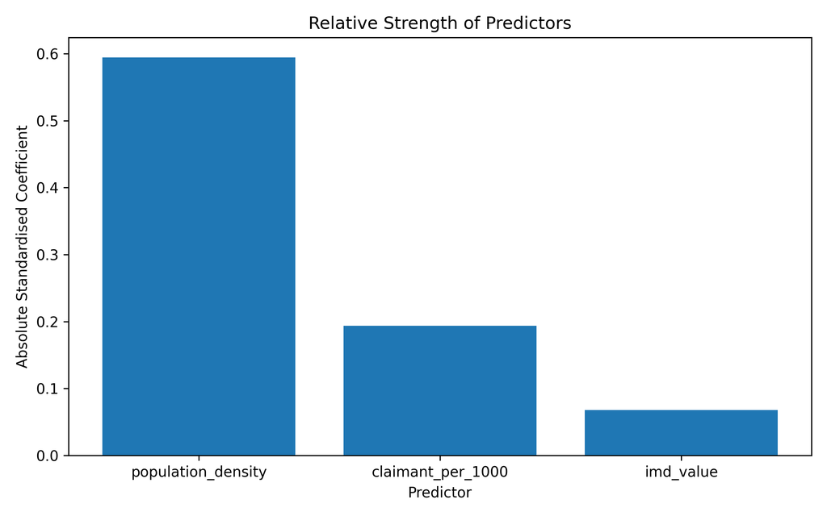

```python
show_fig("predictor_strengths.png")
```

The strongest evidence comes when all three predictors are compared together in one standardised model. In that final comparison, population_density remains the largest coefficient at 0.5946. The second strongest predictor is claimant_per_1000 (-0.1937), while imd_value (0.0676) is the weakest. The model’s R-squared is 0.2937, meaning it explains part of the borough variation, but not all of it.

This is the key result of the whole project. Density is not only the strongest simple relationship; it is also the strongest variable once the three predictors are assessed side by side on the same scale. That makes it the clearest answer to the research question.

## What this result does and does not show

The model also explains only part of the variation in crime. So while density is the clearest predictor among the variables tested, it is not the whole story.

## Conclusion

So, which borough-level factor is most strongly associated with crime per 1,000 population across London from 2019 to 2024?